# Proyecto personal de análisis de datos

Juan José Rodríguez Maulén

23 May 2022

Evaluación de la Madurez en Salmon Coho (Coho Salmon (COS))

Descripción del problema a analizar Se observó madurez en peces cultivados en la región de Los Lagos, sometidos a regimen de fotoperiodo para prevenir la madurez. El proveedor de fotoperiodo correspondió a la empresa BIOLED quienes utilizaron 3 intensidades lumínicas (W) en centros de cultivos de peces provenientes de las pisciculturas Huincara, Coipue, Lican y Lago Rupanco. En terminos de madurez observada por mix de jaulas, estas fluctuaron entre un 0 a un 20%, mientras que a nivel de centro de cultivo, esta alcanzo un 6,81% siendo aceptable un 5%.

Descripción de las variables de estudio, factores a analizar y el número total de observaciones Los datos de madurez, correspondieron a las observaciones realizadas en plantas de proceso, para la clasificación de calidades, donde una de las causales de degradación correspondio a madurez por jaula y centro de cultivo

Variable respuesta= % de maduración (Cuantitativa Discreta) Variable explicativa= Centro de Cultivo (Cualitativa Nominal) y Potencia (W) (Cuantitativa Discreta) N= 220 observaciones.

## Utiliza paquetes para importar y analizar

```r
knitr::opts_chunk$set(echo = TRUE)
## En este bloque de código podrían ir todos los paquetes que necesite habilitar o install.packages
library(datasets)
library(ggplot2)
library(readxl)
library(stats)
install.packages("lme4")
library(lme4)
library(Matrix)
library(psych)
library(readr)
library(tidyverse)
library(janitor)
library(scales)
library(ggthemes)
library(ggrepel)
```

```r
Madurez <- read_excel("/cloud/project/Coho Season 2021-2022.xlsx",na="NA", sheet = 2)

#Madurez <- na.omit(Madurez)
```

```r
summary(Madurez)
```

```
##  Jaula individual  Site Name             Cage           % Deformation
##  Min.   :0.0000   Length:220         Length:220         Min.   :0.0003672
##  1st Qu.:0.0000   Class :character   Class :character   1st Qu.:0.0185166
##  Median :0.0000   Mode  :character   Mode  :character   Median :0.0298002
##  Mean   :0.3636                                         Mean   :0.0382878
##  3rd Qu.:1.0000                                         3rd Qu.:0.0504012
##  Max.   :1.0000                                         Max.   :0.1985384
##                                                         NA's   :1
##     %Mature        % Desadaptado        Origen          Tipo orgien
##  Min.   :0.00000   Min.   :0.00000   Length:220         Length:220
##  1st Qu.:0.00000   1st Qu.:0.00355   Class :character   Class :character
##  Median :0.00000   Median :0.01276   Mode  :character   Mode  :character
##  Mean   :0.01760   Mean   :0.02100
##  3rd Qu.:0.02161   3rd Qu.:0.03070
##  Max.   :0.16881   Max.   :0.11803
##                    NA's   :141
##   Fotoperiodo      Proveedor            Potencia
##  Min.   :0.0000   Length:220         Min.   :   0
##  1st Qu.:0.0000   Class :character   1st Qu.:   0
##  Median :0.0000   Mode  :character   Median :   0
##  Mean   :0.4773                      Mean   :1143
##  3rd Qu.:1.0000                      3rd Qu.:2400
##  Max.   :1.0000                      Max.   :3600
##
```

```r
str(Madurez)
```

```
## tibble [220 × 11] (S3: tbl_df/tbl/data.frame)
##  $ Jaula individual: num [1:220] 1 1 1 1 0 0 0 0 0 0 ...
##  $ Site Name       : chr [1:220] "Teupa" "Teupa" "Teupa" "Teupa" ...
##  $ Cage            : chr [1:220] "102" "103" "104" "107" ...
##  $ % Deformation   : num [1:220] 0.068 0.0451 0.0464 0.0692 0.0117 ...
##  $ %Mature         : num [1:220] 0 0 0 0 0.00553 ...
##  $ % Desadaptado   : num [1:220] 0.01085 0.00675 0.00766 0.01021 NA ...
##  $ Origen          : chr [1:220] "HUINCACARA" "HUINCACARA" "HUINCACARA" "HUINCACARA" ...
##  $ Tipo orgien     : chr [1:220] "Piscicultura" "Piscicultura" "Piscicultura" "Piscicultura" ...
##  $ Fotoperiodo     : num [1:220] 0 0 0 0 0 0 0 0 0 0 ...
##  $ Proveedor       : chr [1:220] "No" "No" "No" "No" ...
##  $ Potencia        : num [1:220] 0 0 0 0 0 0 0 0 0 0 ...
```

```r
head(Madurez)
```

```
## # A tibble: 6 × 11
##   `Jaula individual` `Site Name` Cage  `% Deformation` `%Mature` `% Desadaptado`
##                <dbl> <chr>       <chr>           <dbl>     <dbl>           <dbl>
## 1                  1 Teupa       102            0.0680   0               0.0109
## 2                  1 Teupa       103            0.0451   0               0.00675
## 3                  1 Teupa       104            0.0464   0               0.00766
## 4                  1 Teupa       107            0.0692   0               0.0102
## 5                  0 Teupa       101/…          0.0117   0.00553        NA
## 6                  0 Teupa       101-…          0.0334   0              NA
## # … with 5 more variables: Origen <chr>, `Tipo orgien` <chr>,
## #   Fotoperiodo <dbl>, Proveedor <chr>, Potencia <dbl>
```

```r
#Madurez$`Jaula individual`<-as.factor(Madurez$`Jaula individual`)
#Madurez$Fotoperiodo <- as.factor(Madurez$Fotoperiodo)
```

## Describa la variación de las variables usando histogramas

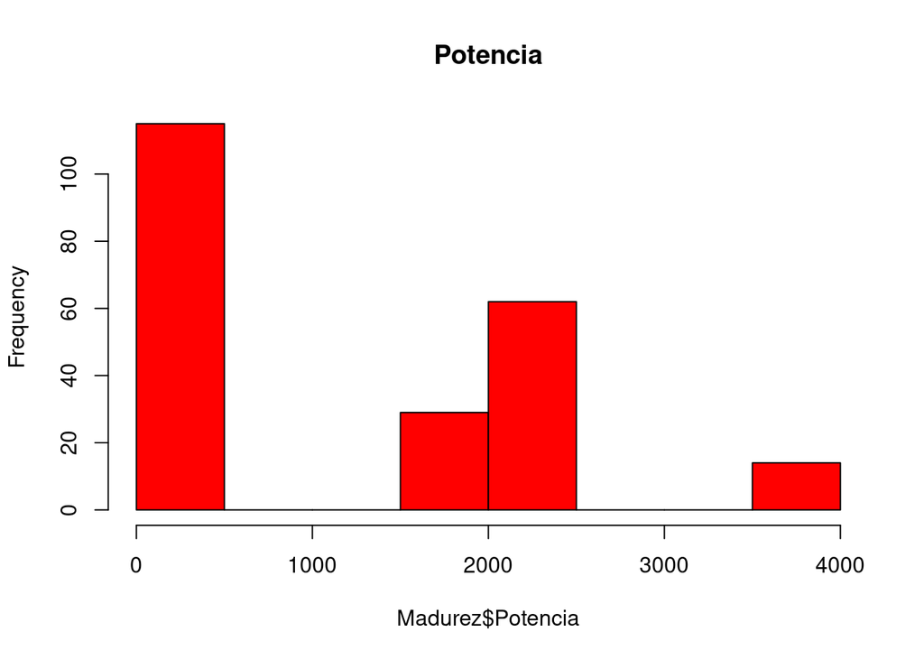

```r
#Describe la variación de las variables de estudio usando histograma
#hist(Madurez$Fotoperiodo,  main = "Fotoperiodo", col = "red")
hist(Madurez$Potencia, main = "Potencia", col = "red")
```

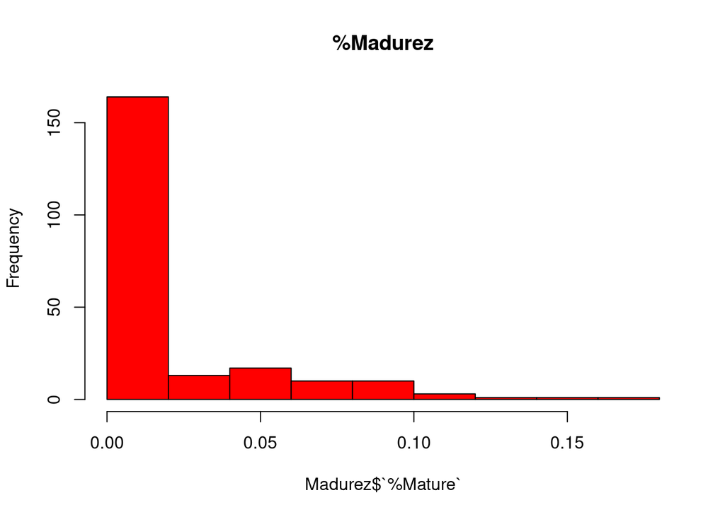

```r
hist(Madurez$`%Mature`,main = "%Madurez", col = "red")
```

[figure not shown]

```r
Ma<-table(Madurez$`%Mature`)
Fo<-table(Madurez$Fotoperiodo)
Po<-table(Madurez$Potencia)
barplot(Ma,col="deepskyblue4",  ylim=c(0,25))
```

[figure not shown]

```r
barplot(Fo,col="deepskyblue4",  ylim=c(0,25))
```

[figure not shown]

```r
barplot(Po,col="deepskyblue4",  ylim=c(0,25))
```

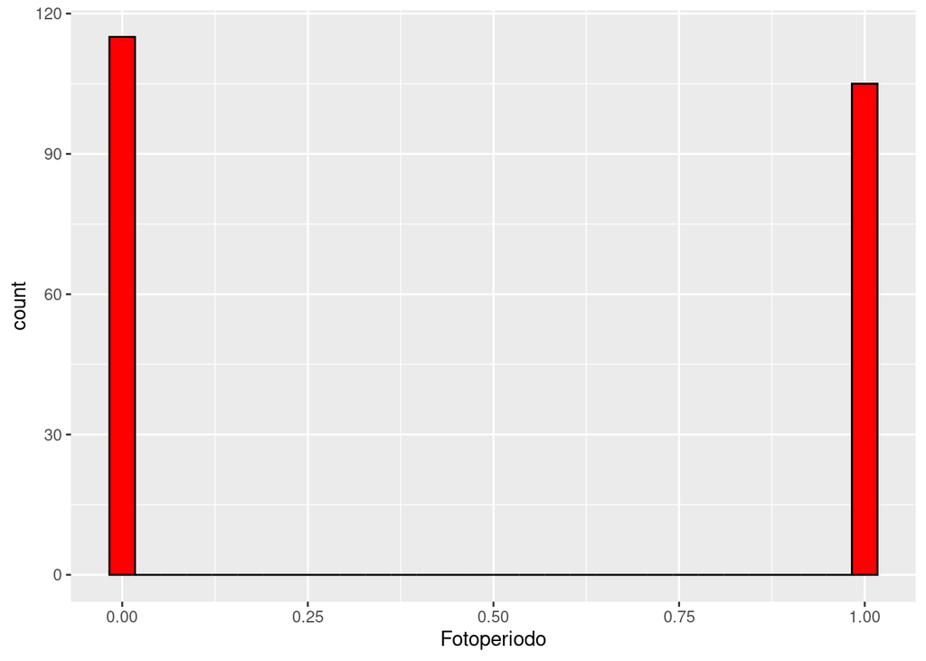

```r
ggplot(Madurez, aes(x = Fotoperiodo)) +geom_histogram(bins = 30, color = "black", fill="red")
```

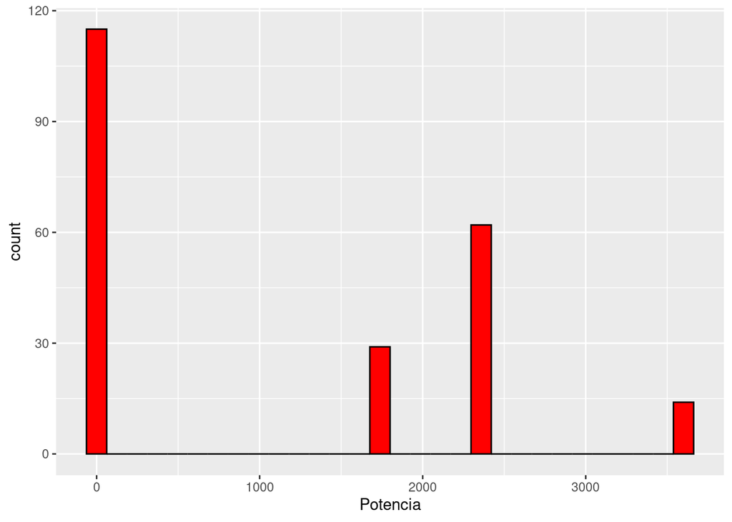

```r
ggplot(Madurez, aes(x = Potencia)) +geom_histogram(bins = 30, color = "black", fill="red")
```

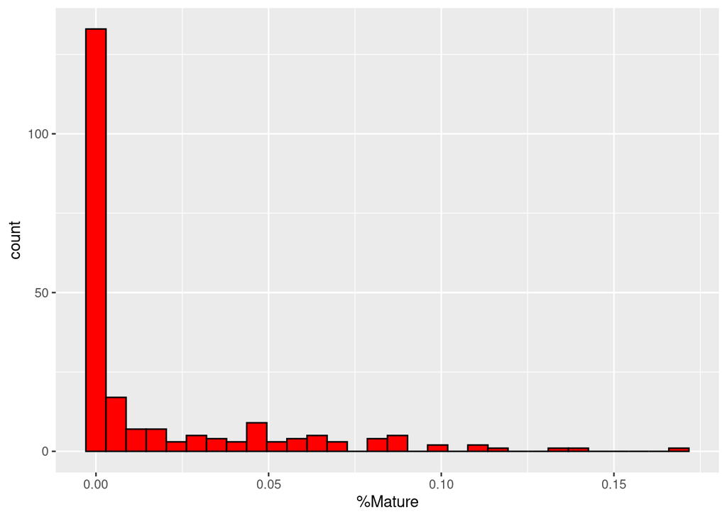

```r
ggplot(Madurez, aes(x = `%Mature`)) +geom_histogram(bins = 30, color = "black", fill="red")
```

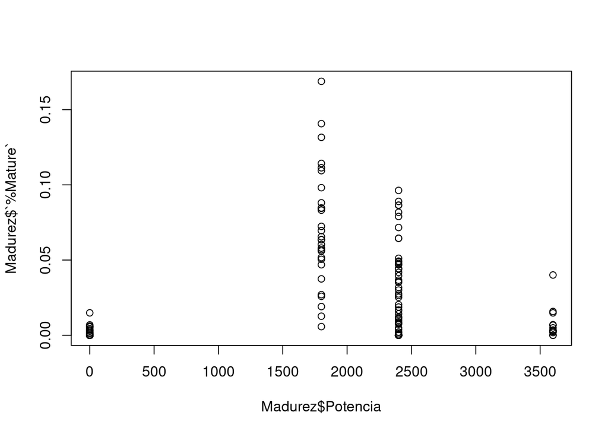

```r
plot(Madurez$`%Mature`~Madurez$Potencia)
```

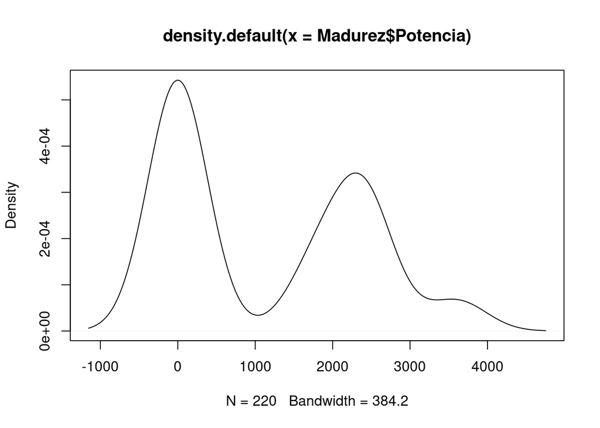

```r
plot(density(Madurez$Potencia))
```

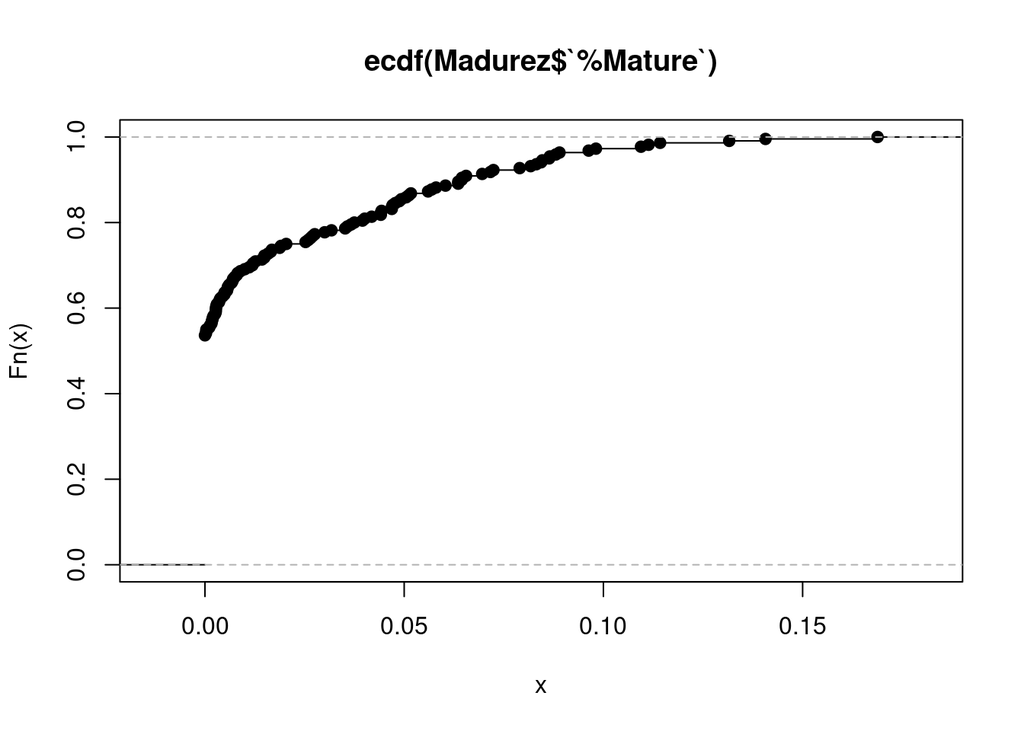

```r
plot(ecdf(Madurez$`%Mature`))
```

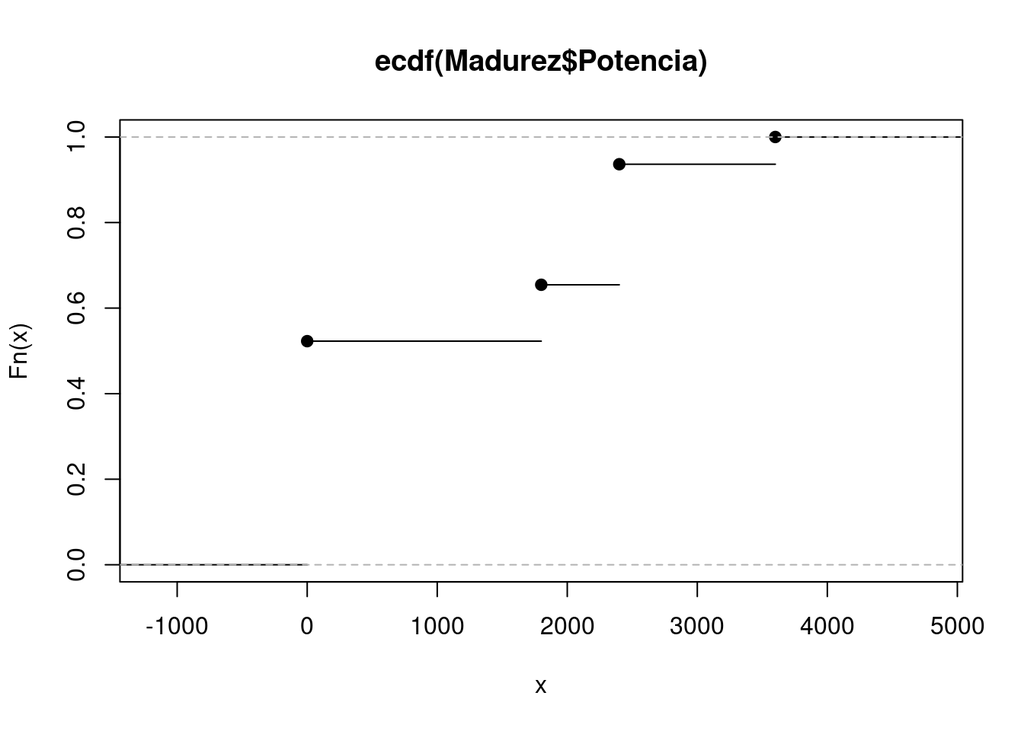

```r
plot(ecdf(Madurez$Potencia))
```

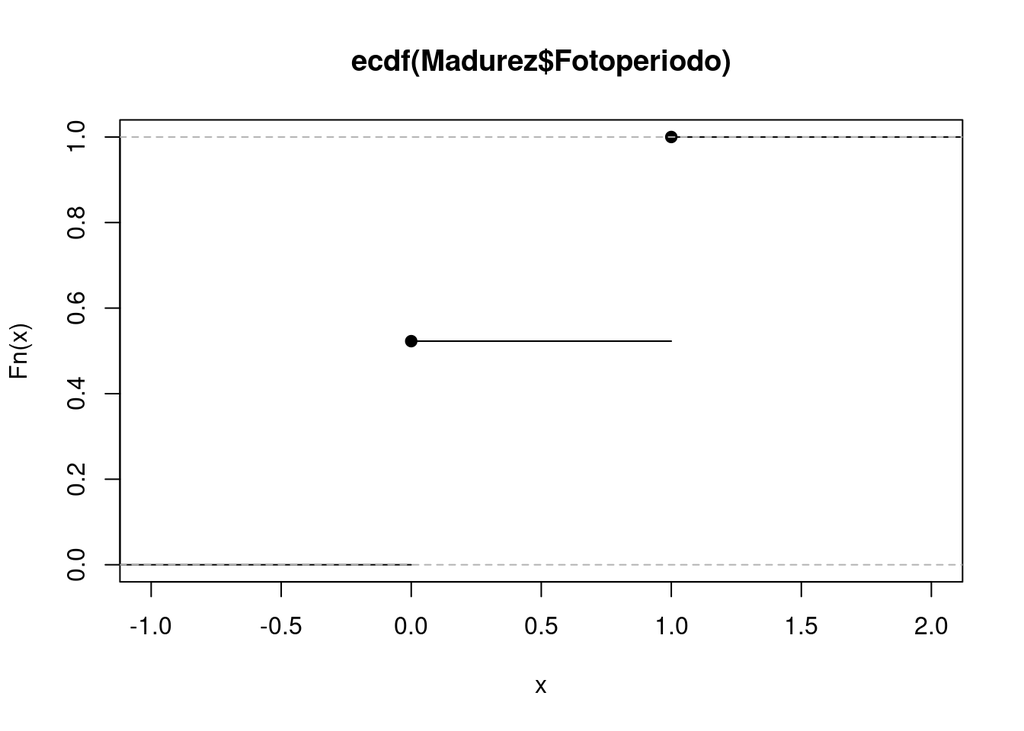

```r
plot(ecdf(Madurez$Fotoperiodo))
```

## Exploración por Proveedor

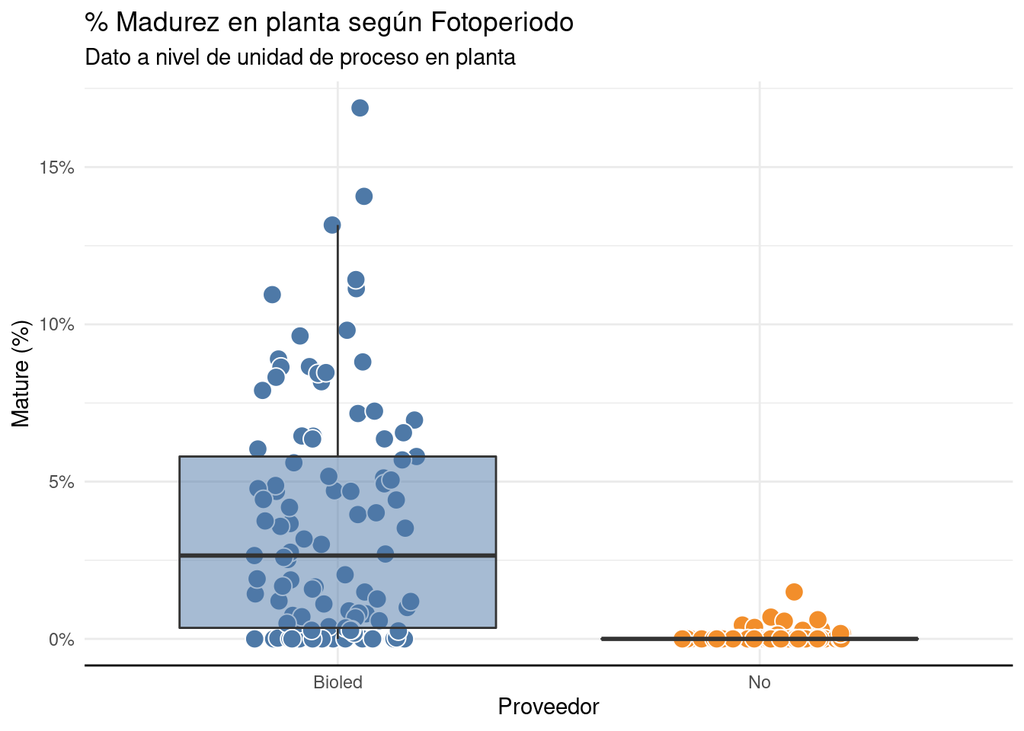

```r
# Madurez ~ Proveedor
Madurez <- read_excel("Coho Season 2021-2022.xlsx", sheet = 2) %>%
  clean_names()
(Madurez <- Madurez %>%
   filter(!is.na(percent_mature)) %>%
   mutate(proveedor = fct_relevel(proveedor)) %>%
  ggplot(aes(proveedor, percent_mature, fill=proveedor)) +
   geom_jitter(shape=21, size=4, color="white", width = 0.2) +
   geom_boxplot(alpha=.5, outlier.color = "NA") +
   scale_fill_tableau() +
   theme_minimal() +
   scale_y_continuous(labels = percent) +
   labs(title="% Madurez en planta según Fotoperiodo",
        subtitle = "Dato a nivel de unidad de proceso en planta") +
   theme(axis.line.x = element_line(),legend.position='none')
)+
labs( x="Proveedor",
     y="Mature (%)")
```

## Exploración por Centro & Fotoperiodo

```r
#Madurez  ~ Centro + Fotoperiodo
Madurez <- read_excel("Coho Season 2021-2022.xlsx", sheet = 2) %>%
  clean_names()
Madurez$site_name <- factor(Madurez$site_name, levels = c('Chidhuapi 1', 'Chope','Chidhuapi 2', 'Colaco 4','Punta Yoye','Teupa', 'Compu', 'Aulin','Cachihue', 'Chidhuapi 3','Linguar','Malomacum'))
Madurez
```

```
## # A tibble: 220 × 11
##    jaula_individual site_name cage    percent_deformation percent_mature
##               <dbl> <fct>     <chr>                 <dbl>          <dbl>
##  1                1 Teupa     102                  0.0680        0
##  2                1 Teupa     103                  0.0451        0
##  3                1 Teupa     104                  0.0464        0
##  4                1 Teupa     107                  0.0692        0
##  5                0 Teupa     101/105              0.0117        0.00553
##  6                0 Teupa     101-108              0.0334        0
##  7                0 Teupa     102/107              0.0539        0
##  8                0 Teupa     102-103              0.0975        0
##  9                0 Teupa     103-108              0.0658        0
## 10                0 Teupa     104-106              0.0914        0
## # … with 210 more rows, and 6 more variables: percent_desadaptado <dbl>,
## #   origen <chr>, tipo_orgien <chr>, fotoperiodo <dbl>, proveedor <chr>,
## #   potencia <dbl>
```

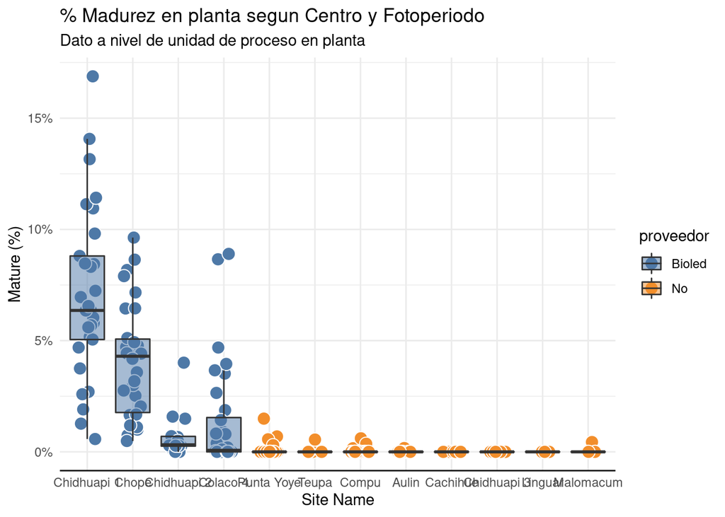

```r
(Madurez <- Madurez %>%
   filter(!is.na(percent_mature)) %>%
   mutate(proveedor = fct_relevel(proveedor)) %>%
   ggplot(aes(site_name, percent_mature, fill=proveedor)) +
   geom_jitter(shape=21, size=4, color="white", width = 0.2) +
   geom_boxplot(alpha=.5, outlier.color = "NA") +
   scale_fill_tableau() +
   theme_minimal() +
   scale_y_continuous(labels = percent) +
   labs(title="% Madurez en planta segun Centro y Fotoperiodo",
        subtitle = "Dato a nivel de unidad de proceso en planta") +
   theme(axis.line.x = element_line())
)+
  labs( x="Site Name",
        y="Mature (%)")
```

## Exploración por Madurez & Potencia

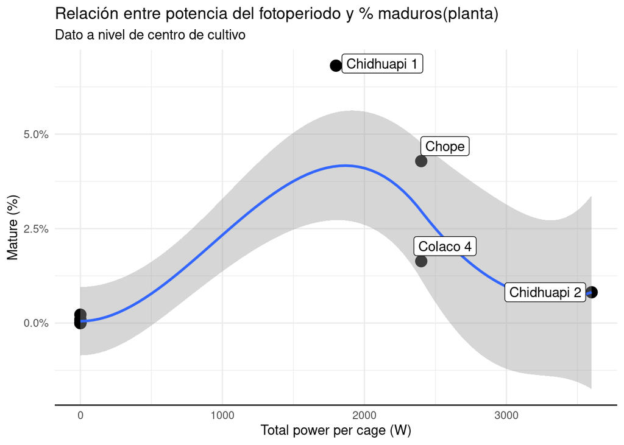

```r
##Madurez ~ Potencia
datos_centro <- read_excel("Coho Season 2021-2022.xlsx", sheet = "Site detail", skip = 2) %>%
  clean_names()
#maduros-potencia (W)
(maduros_potencia_centro <- datos_centro %>%
   ggplot(aes(potencia,percent_maduro)) +
   geom_point(size=4) +
   geom_smooth() +
   theme_minimal() +
   #scale_x_continuous(labels = percent) +
   scale_y_continuous(labels = percent) +
   geom_label_repel(aes(label=site_name)) +
   labs(title="Relación entre potencia del fotoperiodo y % maduros(planta)",
        subtitle = "Dato a nivel de centro de cultivo") +
   theme(axis.line.x = element_line())
)+
labs( x="Total power per cage (W)",
        y="Mature (%)")#+
```

```r
#ylim(0,7)
```

```r
Ma<-table(Madurez$`%Mature`)
Fo<-table(Madurez$Fotoperiodo)
Po<-table(Madurez$Potencia)
mean(Madurez$`%Mature`)
```

```
## [1] NA
```

```r
mean(Madurez$Fotoperiodo)
```

```
## [1] NA
```

```r
mean(Madurez$Potencia)
```

```
## [1] NA
```

```r
sd(Madurez$`%Mature`)
```

```
## [1] NA
```

```r
sd(Madurez$Fotoperiodo)
```

```
## [1] NA
```

```r
sd(Madurez$Potencia)
```

```
## [1] NA
```

# Conclusiones

De acuerdo a la exploración de datos, se puede evidenciar que el proveedor fotoperiodo, presento maduración en los centros de cultivos donde se implentó la estrategia en comparación con los centros de cultivo donde no se encontraba implementada la estrategia de Fotoperiodo.

El Centro de Cultivo que presentó mayor madurez (> 5%) correspondio al centro Chidhuapi 1

Enlace a proyecto Github: https://github.com/Ictiosapiens/Tarea_DiplomadoR